# Assignment4-StochasticModels

Claijon da Silva

18/08/2017

## Introduction

This exercice will make the use of the Latent Class Analysis to investigate group similarities and clusters.

## Data

Nine hundred and forty three students were asked whether they very highly rated six different Harrison Ford movies or not (1=Yes, 0=No). A summary of the data is as follows:

```
##   SW ESB RJ LC LA F
## 1  1   1  1  1  1 1
## 2  1   0  0  0  0 0
## 3  0   0  1  0  0 0
## 4  1   0  0  1  0 0
## 5  1   1  1  1  1 1
## 6  1   0  0  0  1 1
```

```
##    SW ESB  RJ  LC  LA   F
## 1 558 350 476 314 403 323
```

- SW Star Wars
- ESB The Empire Strikes Back
- RJ Return of the Jedi
- LC Indiana Jones and the Last Crusade
- LA Raiders of the Last Ark
- F The Fugitive

### The Latent Class Analysis

Checking groups from 1 to 6 and choosing the highest BIC

```
## [1] -7567.014 -5597.416 -5403.301 -5320.906 -5330.198 -5362.547
```

```
## Groups: 4 BIC: -5320.906
```

### The Latent Class Analysis For 4 Groups

Group probabilities Group 1 Group 2 Group 3 Group 4 0.350 0.339 0.192 0.119

Within the groups, ie group 1, the probability for very high rate:

- Star Wars is 99.6 %
- The Empire Strikes Back is 91.12%
- Return of the Jedi is 94.4%
- Indiana Jones and the Last Crusade is 76.8%
- Raiders of the Lost Ark is 95.3%
- The Fugitive is 73.2%

| Groups | SW | ESB | RJ | LC | LA | F |
| --- | --- | --- | --- | --- | --- | --- |
| 1 | 0.996 | 0.913 | 0.945 | 0.769 | 0.954 | 0.732 |
| 2 | 0.005 | 0.022 | 0.050 | 0.015 | 0.001 | 0.054 |
| 3 | 0.998 | 0.071 | 0.725 | 0.073 | 0.074 | 0.053 |
| 4 | 0.428 | 0.268 | 0.157 | 0.385 | 0.679 | 0.496 |

## Graph The Result

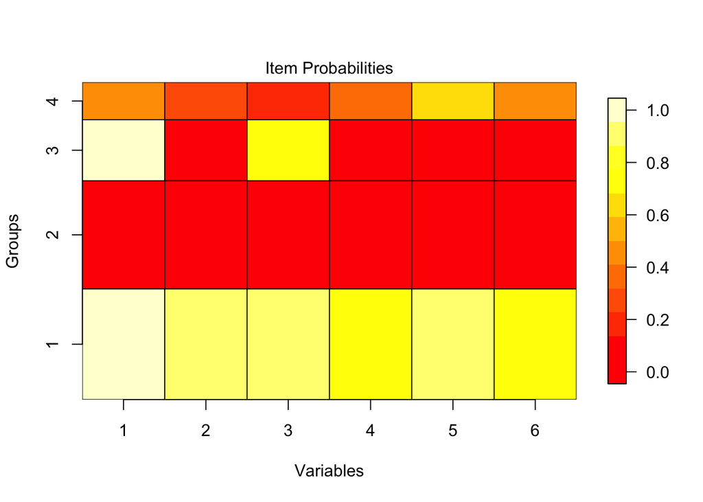